# Bike Sharing Demand Analysis

[figure not shown]

## Introduction :

Bike sharing systems are new generation of traditional bike rentals where whole process from membership, rental and return back has become automatic. Through these systems, user is able to easily rent a bike from a particular position and return back at another position. Currently, there are about over 500 bike-sharing programs around the world which is composed of over 500 thousands bicycles. Today, there exists great interest in these systems due to their important role in traffic, environmental and health issues.

Apart from interesting real world applications of bike sharing systems, the characteristics of data being generated by these systems make them attractive for the research. Opposed to other transport services such as bus or subway, the duration of travel, departure and arrival position is explicitly recorded in these systems. This feature turns bike sharing system into a virtual sensor network that can be used for sensing mobility in the city. Hence, it is expected that most of important events in the city could be detected via monitoring these data.

## Description of Dataset :

- This dataset contains the hourly and daily count of rental bikes between years 2011 and 2012 in Capital bikeshare system with the corresponding weather and seasonal information.

Both hour.csv and day.csv have the following fields, except hr which is not available in day.csv

**1. instant :** record index

**2. dteday :** date

**3. season :** season (1:winter, 2:spring, 3:summer, 4:fall)

**4. yr :** year (0: 2011, 1:2012)

**5. mnth :** month ( 1 to 12)

**6. hr :** hour (0 to 23)

**7. holiday :** weather day is holiday or not (extracted from [Web Link])

**8. weekday :** day of the week

**9. workingday :** if day is neither weekend nor holiday is 1, otherwise is 0.

**10. weathersit :**

```
  1: Clear, Few clouds, Partly cloudy, Partly cloudy
  2: Mist + Cloudy, Mist + Broken clouds, Mist + Few clouds, Mist
  3: Light Snow, Light Rain + Thunderstorm + Scattered clouds, Light Rain + Scattered clouds
  4: Heavy Rain + Ice Pallets + Thunderstorm + Mist, Snow + Fog
```

**11. temp :** Normalized temperature in Celsius. The values are derived via (t-t_min)/(t_max-t_min), t_min=-8, t_max=+39 (only in hourly scale)

**12. atemp :** Normalized feeling temperature in Celsius. The values are derived via (t-t_min)/(t_max-t_min), t_min=-16, t_max=+50 (only in hourly scale)

**13. hum :** Normalized humidity. The values are divided to 100 (max)

**14. windspeed :** Normalized wind speed. The values are divided to 67 (max)

**15. casual :** count of casual users

**16. registered :** count of registered users

**17. cnt :** count of total rental bikes including both casual and registered

## Dataset Source :

https://archive.ics.uci.edu/ml/datasets/Bike+Sharing+Dataset

Original Source : http://capitalbikeshare.com/system-data

Weather Information : http://www.freemeteo.com

Holiday Schedule : http://dchr.dc.gov/page/holiday-schedule

## Importing Libraries

```python
import pandas as pd
import numpy as np
import seaborn as sns
import matplotlib.pyplot as plt
%matplotlib inline
import plotly.graph_objs as go
import plotly.offline as py

import warnings
warnings.filterwarnings('ignore')
```

## Importing the Dataset

```python
data = pd.read_csv("hour.csv")
```

```python
data.head()
```

|  | instant | dteday | season | yr | mnth | hr | holiday | weekday | workingday | weathersit | temp | atemp | hum | windspeed | casual | registered | cnt |
| --- | --- | --- | --- | --- | --- | --- | --- | --- | --- | --- | --- | --- | --- | --- | --- | --- | --- |
| 0 | 1 | 2011-01-01 | 1 | 0 | 1 | 0 | 0 | 6 | 0 | 1 | 0.24 | 0.2879 | 0.81 | 0.0 | 3 | 13 | 16 |
| 1 | 2 | 2011-01-01 | 1 | 0 | 1 | 1 | 0 | 6 | 0 | 1 | 0.22 | 0.2727 | 0.80 | 0.0 | 8 | 32 | 40 |
| 2 | 3 | 2011-01-01 | 1 | 0 | 1 | 2 | 0 | 6 | 0 | 1 | 0.22 | 0.2727 | 0.80 | 0.0 | 5 | 27 | 32 |
| 3 | 4 | 2011-01-01 | 1 | 0 | 1 | 3 | 0 | 6 | 0 | 1 | 0.24 | 0.2879 | 0.75 | 0.0 | 3 | 10 | 13 |
| 4 | 5 | 2011-01-01 | 1 | 0 | 1 | 4 | 0 | 6 | 0 | 1 | 0.24 | 0.2879 | 0.75 | 0.0 | 0 | 1 | 1 |

```python
data.shape
```

```
(17379, 17)
```

## Summary of Data

```python
data.info()
```

```
<class 'pandas.core.frame.DataFrame'>
RangeIndex: 17379 entries, 0 to 17378
Data columns (total 17 columns):
 #   Column      Non-Null Count  Dtype
---  ------      --------------  -----
 0   instant     17379 non-null  int64
 1   dteday      17379 non-null  object
 2   season      17379 non-null  int64
 3   yr          17379 non-null  int64
 4   mnth        17379 non-null  int64
 5   hr          17379 non-null  int64
 6   holiday     17379 non-null  int64
 7   weekday     17379 non-null  int64
 8   workingday  17379 non-null  int64
 9   weathersit  17379 non-null  int64
 10  temp        17379 non-null  float64
 11  atemp       17379 non-null  float64
 12  hum         17379 non-null  float64
 13  windspeed   17379 non-null  float64
 14  casual      17379 non-null  int64
 15  registered  17379 non-null  int64
 16  cnt         17379 non-null  int64
dtypes: float64(4), int64(12), object(1)
memory usage: 2.3+ MB
```

```python
data.describe().T
```

|  | count | mean | std | min | 25% | 50% | 75% | max |
| --- | --- | --- | --- | --- | --- | --- | --- | --- |
| instant | 17379.0 | 8690.000000 | 5017.029500 | 1.00 | 4345.5000 | 8690.0000 | 13034.5000 | 17379.0000 |
| season | 17379.0 | 2.501640 | 1.106918 | 1.00 | 2.0000 | 3.0000 | 3.0000 | 4.0000 |
| yr | 17379.0 | 0.502561 | 0.500008 | 0.00 | 0.0000 | 1.0000 | 1.0000 | 1.0000 |
| mnth | 17379.0 | 6.537775 | 3.438776 | 1.00 | 4.0000 | 7.0000 | 10.0000 | 12.0000 |
| hr | 17379.0 | 11.546752 | 6.914405 | 0.00 | 6.0000 | 12.0000 | 18.0000 | 23.0000 |
| holiday | 17379.0 | 0.028770 | 0.167165 | 0.00 | 0.0000 | 0.0000 | 0.0000 | 1.0000 |
| weekday | 17379.0 | 3.003683 | 2.005771 | 0.00 | 1.0000 | 3.0000 | 5.0000 | 6.0000 |
| workingday | 17379.0 | 0.682721 | 0.465431 | 0.00 | 0.0000 | 1.0000 | 1.0000 | 1.0000 |
| weathersit | 17379.0 | 1.425283 | 0.639357 | 1.00 | 1.0000 | 1.0000 | 2.0000 | 4.0000 |
| temp | 17379.0 | 0.496987 | 0.192556 | 0.02 | 0.3400 | 0.5000 | 0.6600 | 1.0000 |
| atemp | 17379.0 | 0.475775 | 0.171850 | 0.00 | 0.3333 | 0.4848 | 0.6212 | 1.0000 |
| hum | 17379.0 | 0.627229 | 0.192930 | 0.00 | 0.4800 | 0.6300 | 0.7800 | 1.0000 |
| windspeed | 17379.0 | 0.190098 | 0.122340 | 0.00 | 0.1045 | 0.1940 | 0.2537 | 0.8507 |
| casual | 17379.0 | 35.676218 | 49.305030 | 0.00 | 4.0000 | 17.0000 | 48.0000 | 367.0000 |
| registered | 17379.0 | 153.786869 | 151.357286 | 0.00 | 34.0000 | 115.0000 | 220.0000 | 886.0000 |
| cnt | 17379.0 | 189.463088 | 181.387599 | 1.00 | 40.0000 | 142.0000 | 281.0000 | 977.0000 |

## Total Missing Values

```python
data.isnull().sum()
```

```
instant       0
dteday        0
season        0
yr            0
mnth          0
hr            0
holiday       0
weekday       0
workingday    0
weathersit    0
temp          0
atemp         0
hum           0
windspeed     0
casual        0
registered    0
cnt           0
dtype: int64
```

- NO missing values

## Pre processing the dataset

```python
data = data.rename(columns = {'weathersit':'weather', 'yr':'year', 'mnth':'month', 'hr':'hour', 'hum':'humidity',
                              'cnt':'count'})
data.head()
```

|  | instant | dteday | season | year | month | hour | holiday | weekday | workingday | weather | temp | atemp | humidity | windspeed | casual | registered | count |
| --- | --- | --- | --- | --- | --- | --- | --- | --- | --- | --- | --- | --- | --- | --- | --- | --- | --- |
| 0 | 1 | 2011-01-01 | 1 | 0 | 1 | 0 | 0 | 6 | 0 | 1 | 0.24 | 0.2879 | 0.81 | 0.0 | 3 | 13 | 16 |
| 1 | 2 | 2011-01-01 | 1 | 0 | 1 | 1 | 0 | 6 | 0 | 1 | 0.22 | 0.2727 | 0.80 | 0.0 | 8 | 32 | 40 |
| 2 | 3 | 2011-01-01 | 1 | 0 | 1 | 2 | 0 | 6 | 0 | 1 | 0.22 | 0.2727 | 0.80 | 0.0 | 5 | 27 | 32 |
| 3 | 4 | 2011-01-01 | 1 | 0 | 1 | 3 | 0 | 6 | 0 | 1 | 0.24 | 0.2879 | 0.75 | 0.0 | 3 | 10 | 13 |
| 4 | 5 | 2011-01-01 | 1 | 0 | 1 | 4 | 0 | 6 | 0 | 1 | 0.24 | 0.2879 | 0.75 | 0.0 | 0 | 1 | 1 |

```python
data = data.drop(columns = ['instant', 'dteday', 'year'])
```

```python
# change int columns to category
cols = ['season', 'month', 'hour', 'holiday', 'weekday', 'workingday', 'weather']

for col in cols:
    data[col] = data[col].astype('category')
data.info()
```

```
<class 'pandas.core.frame.DataFrame'>
RangeIndex: 17379 entries, 0 to 17378
Data columns (total 14 columns):
 #   Column      Non-Null Count  Dtype
---  ------      --------------  -----
 0   season      17379 non-null  category
 1   month       17379 non-null  category
 2   hour        17379 non-null  category
 3   holiday     17379 non-null  category
 4   weekday     17379 non-null  category
 5   workingday  17379 non-null  category
 6   weather     17379 non-null  category
 7   temp        17379 non-null  float64
 8   atemp       17379 non-null  float64
 9   humidity    17379 non-null  float64
 10  windspeed   17379 non-null  float64
 11  casual      17379 non-null  int64
 12  registered  17379 non-null  int64
 13  count       17379 non-null  int64
dtypes: category(7), float64(4), int64(3)
memory usage: 1.0 MB
```

```
[Text(0.5, 1.0, 'Count of bikes during weekdays and weekends')]
```

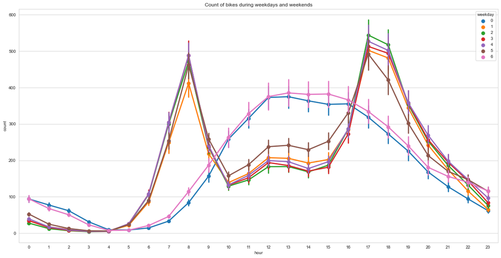

```python
sns.set_style("whitegrid")
fig, ax = plt.subplots(figsize = (20,10))
sns.pointplot(data = data, x = 'hour', y = 'count', hue = 'weekday', ax = ax)
ax.set(title = 'Count of bikes during weekdays and weekends')
```

```
[Text(0.5, 1.0, 'Count of bikes during weekdays and weekends: Unregistered users')]
```

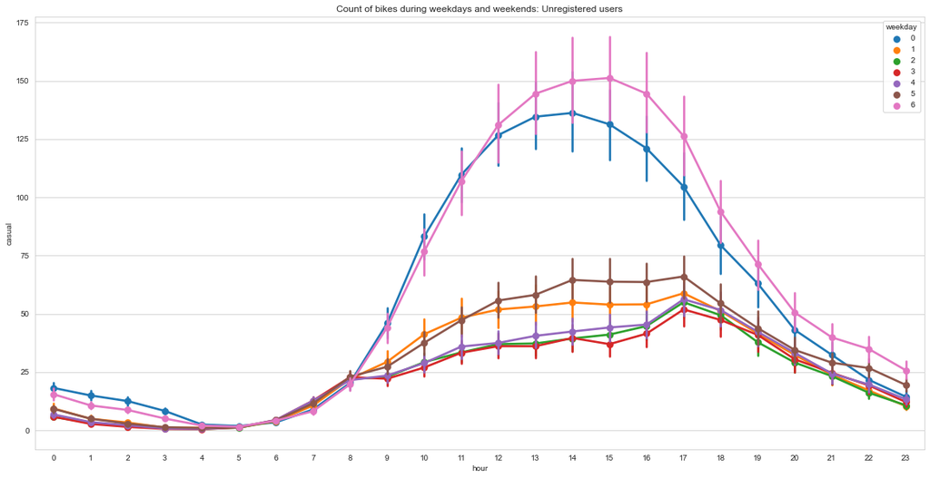

```python
fig, ax = plt.subplots(figsize = (20,10))
sns.pointplot(data = data, x = 'hour', y = 'casual', hue = 'weekday', ax = ax)
ax.set(title='Count of bikes during weekdays and weekends: Unregistered users')
```

```
[Text(0.5, 1.0, 'Count of bikes during weekdays and weekends: Registered users')]
```

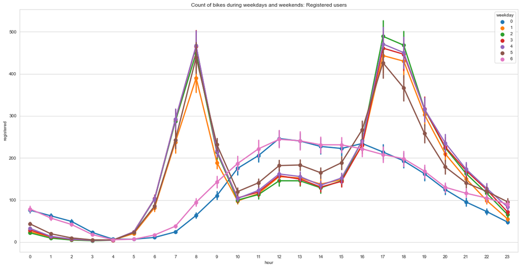

```python
fig, ax = plt.subplots(figsize = (20,10))
sns.pointplot(data = data, x = 'hour', y = 'registered', hue = 'weekday', ax = ax)
ax.set(title = 'Count of bikes during weekdays and weekends: Registered users')
```

```
[Text(0.5, 1.0, 'Count of bikes during different weathers')]
```

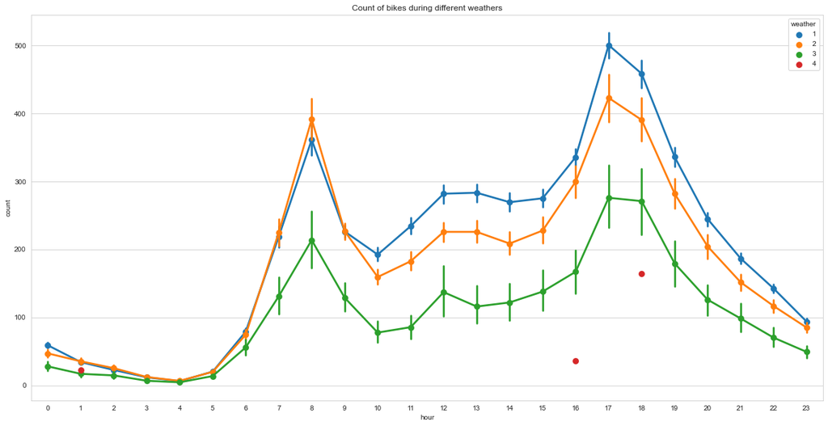

```python
fig, ax = plt.subplots(figsize = (20,10))
sns.pointplot(data = data, x = 'hour', y = 'count', hue = 'weather', ax = ax)
ax.set(title = 'Count of bikes during different weathers')
```

```
[Text(0.5, 1.0, 'Count of bikes during different seasons')]
```

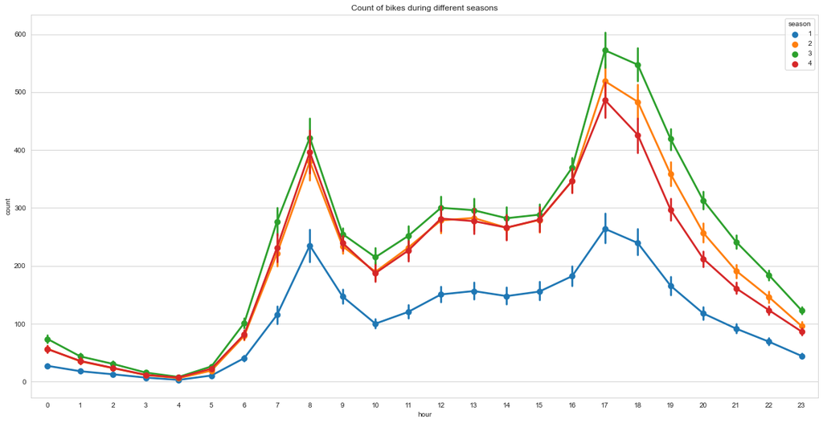

```python
fig, ax = plt.subplots(figsize = (20,10))
sns.pointplot(data = data, x = 'hour', y = 'count', hue = 'season', ax = ax)
ax.set(title = 'Count of bikes during different seasons')
```

```
[Text(0.5, 1.0, 'Count of bikes during different months')]
```

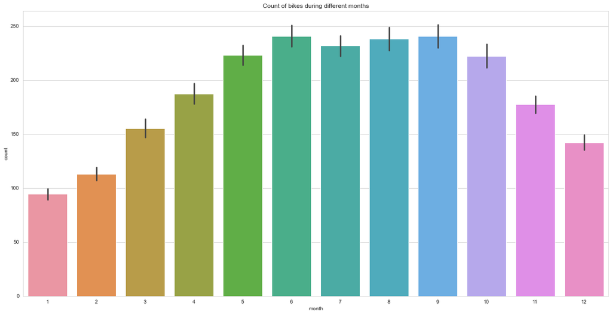

```python
fig, ax = plt.subplots(figsize = (20,10))
sns.barplot(data = data, x = 'month', y = 'count', ax = ax)
ax.set(title = 'Count of bikes during different months')
```

```
[Text(0.5, 1.0, 'Count of bikes during different days')]
```

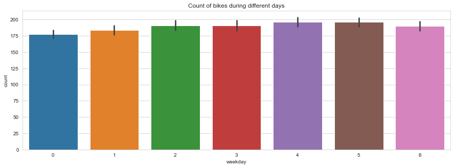

```python
fig, ax = plt.subplots(figsize = (15,5))
sns.barplot(data = data, x = 'weekday', y = 'count', ax = ax)
ax.set(title = 'Count of bikes during different days')
```

```
[Text(0.5, 1.0, 'Relation between humidity and users')]
```

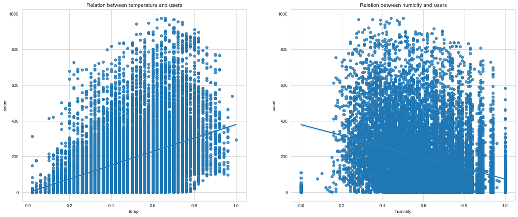

```python
fig, (ax1,ax2) = plt.subplots(ncols = 2, figsize = (20,8))
sns.regplot(x = data['temp'], y = data['count'], ax = ax1)
ax1.set(title = "Relation between temperature and users")
sns.regplot(x = data['humidity'], y = data['count'], ax = ax2)
ax2.set(title = "Relation between humidity and users")
```

```
[Text(0.5, 1.0, 'Theoritical quantiles')]
```

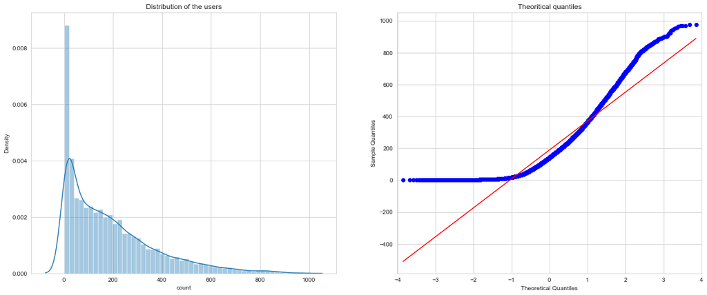

```python
from statsmodels.graphics.gofplots import qqplot
fig, (ax1,ax2) = plt.subplots(ncols = 2, figsize = (20,8))
sns.distplot(data['count'], ax = ax1)
ax1.set(title = 'Distribution of the users')
qqplot(data['count'], ax = ax2, line = 's')
ax2.set(title = 'Theoritical quantiles')
```

```python
data['count'] = np.log(data['count'])
```

```
[Text(0.5, 1.0, 'Theoritical quantiles')]
```

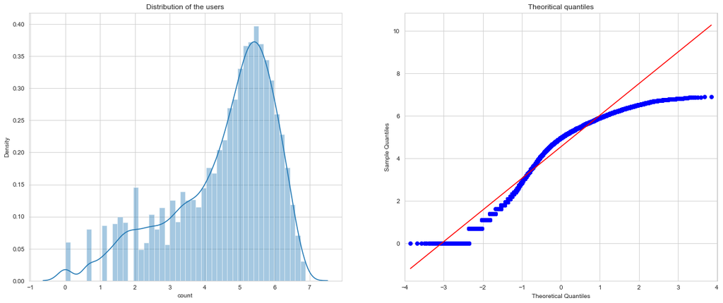

```python
fig, (ax1,ax2) = plt.subplots(ncols = 2, figsize = (20,8))
sns.distplot(data['count'], ax = ax1)
ax1.set(title = 'Distribution of the users')
qqplot(data['count'], ax = ax2, line = 's')
ax2.set(title = 'Theoritical quantiles')
```

## Coorelation Matrix

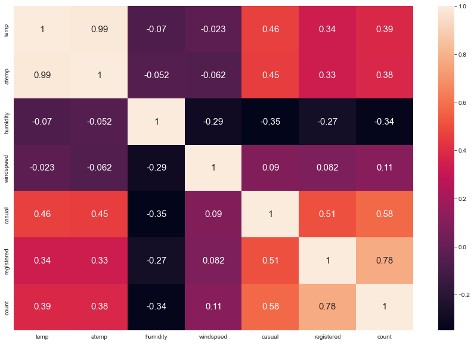

```python
corr = data.corr()
plt.figure(figsize = (15,10))
sns.heatmap(corr, annot = True, annot_kws = {'size':15})
```

## One hot Encoding

```python
pd.get_dummies(data['season'], prefix = 'season', drop_first = True)
```

|  | season_2 | season_3 | season_4 |
| --- | --- | --- | --- |
| 0 | 0 | 0 | 0 |
| 1 | 0 | 0 | 0 |
| 2 | 0 | 0 | 0 |
| 3 | 0 | 0 | 0 |
| 4 | 0 | 0 | 0 |
| ... | ... | ... | ... |
| 17374 | 0 | 0 | 0 |
| 17375 | 0 | 0 | 0 |
| 17376 | 0 | 0 | 0 |
| 17377 | 0 | 0 | 0 |
| 17378 | 0 | 0 | 0 |

17379 rows × 3 columns

```python
df_oh = data

def one_hot_encoding(data, column):
    data = pd.concat([data, pd.get_dummies(data[column], prefix = column, drop_first = True)], axis = 1)
    data = data.drop([column], axis = 1)
    return data

cols = ['season','month','hour','holiday','weekday','workingday','weather']

for col in cols:
    df_oh = one_hot_encoding(df_oh, col)
df_oh.head()
```

|  | temp | atemp | humidity | windspeed | casual | registered | count | season_2 | season_3 | season_4 | ... | weekday_1 | weekday_2 | weekday_3 | weekday_4 | weekday_5 | weekday_6 | workingday_1 | weather_2 | weather_3 | weather_4 |
| --- | --- | --- | --- | --- | --- | --- | --- | --- | --- | --- | --- | --- | --- | --- | --- | --- | --- | --- | --- | --- | --- |
| 0 | 0.24 | 0.2879 | 0.81 | 0.0 | 3 | 13 | 2.772589 | 0 | 0 | 0 | ... | 0 | 0 | 0 | 0 | 0 | 1 | 0 | 0 | 0 | 0 |
| 1 | 0.22 | 0.2727 | 0.80 | 0.0 | 8 | 32 | 3.688879 | 0 | 0 | 0 | ... | 0 | 0 | 0 | 0 | 0 | 1 | 0 | 0 | 0 | 0 |
| 2 | 0.22 | 0.2727 | 0.80 | 0.0 | 5 | 27 | 3.465736 | 0 | 0 | 0 | ... | 0 | 0 | 0 | 0 | 0 | 1 | 0 | 0 | 0 | 0 |
| 3 | 0.24 | 0.2879 | 0.75 | 0.0 | 3 | 10 | 2.564949 | 0 | 0 | 0 | ... | 0 | 0 | 0 | 0 | 0 | 1 | 0 | 0 | 0 | 0 |
| 4 | 0.24 | 0.2879 | 0.75 | 0.0 | 0 | 1 | 0.000000 | 0 | 0 | 0 | ... | 0 | 0 | 0 | 0 | 0 | 1 | 0 | 0 | 0 | 0 |

5 rows × 55 columns

## Data Split

```python
X = df_oh.drop(columns = ['atemp', 'windspeed', 'casual', 'registered', 'count'], axis = 1)
y = df_oh['count']
```

## Model Training

```python
from sklearn.linear_model import LinearRegression, Ridge, HuberRegressor, ElasticNetCV
from sklearn.tree import DecisionTreeRegressor
from sklearn.ensemble import RandomForestRegressor, GradientBoostingRegressor, ExtraTreesRegressor

models = [LinearRegression(),
          Ridge(),
          HuberRegressor(),
          ElasticNetCV(),
          DecisionTreeRegressor(),
          RandomForestRegressor(),
          ExtraTreesRegressor(),
          GradientBoostingRegressor()]
```

```python
from sklearn import model_selection
def train(model):
    kfold = model_selection.KFold(n_splits = 5)
    pred = model_selection.cross_val_score(model, X, y, cv = kfold, scoring = 'neg_mean_squared_error')
    cv_score = pred.mean()
    print('Model:',model)
    print('CV score:', abs(cv_score))
```

```python
for model in models:
    train(model)
```

```
Model: LinearRegression()
CV score: 0.6315351640502703
Model: Ridge()
CV score: 0.6304079414191445
Model: HuberRegressor()
CV score: 0.6603303761426849
Model: ElasticNetCV()
CV score: 0.6252222784219457
Model: DecisionTreeRegressor()
CV score: 0.5992416266968623
Model: RandomForestRegressor()
CV score: 0.39070836279279997
Model: ExtraTreesRegressor()
CV score: 0.40361572981926647
Model: GradientBoostingRegressor()
CV score: 0.4714340374748952
```

```python
from sklearn.model_selection import train_test_split
x_train, x_test, y_train, y_test = train_test_split(X, y, test_size = 0.25, random_state = 42)
```

```python
model = RandomForestRegressor()
model.fit(x_train, y_train)
y_pred = model.predict(x_test)
```

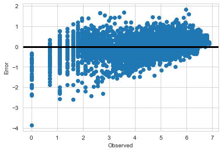

```python
error = y_test - y_pred
fig, ax = plt.subplots()
ax.scatter(y_test, error)
ax.axhline(lw = 3, color = 'black')
ax.set_xlabel('Observed')
ax.set_ylabel('Error')
plt.show()
```

```python
from sklearn.metrics import mean_squared_error
np.sqrt(mean_squared_error(y_test, y_pred))
```

```
0.4825576647980939
```

```python
from sklearn import preprocessing,metrics,linear_model
lr_model = linear_model.LinearRegression()
lr_model
```

```
LinearRegression()
```

```python
lr_model.fit(x_train,y_train)
```

```
LinearRegression()
```

### Accuracy of model

```python
lr = lr_model.score(x_train,y_train)
print('Accuracy of the model :', lr)
print('\n')
print('Model coefficients    :', lr_model.coef_)
print('\n')
print('Model intercept value :', lr_model.intercept_)
```

```
Accuracy of the model : 0.8000082058147222


Model coefficients    : [ 1.70814143 -0.36963162  0.30836203  0.3744368   0.62575645  0.07656814
  0.06104188  0.03877799  0.13593426  0.00676162 -0.1555534  -0.10148498
  0.04334933 -0.0317212  -0.09153142 -0.04783992 -0.60948872 -1.17781157
 -1.71333873 -2.01106797 -0.89605459  0.26995727  1.26672716  1.90443645
  1.56906655  1.21690955  1.31875512  1.50854969  1.47620234  1.36208206
  1.41188593  1.68333787  2.08073119  1.99686605  1.73361348  1.47478773
  1.21970022  0.96460809  0.56506126 -0.16039985 -0.06622154 -0.07931379
 -0.0622757  -0.03043194  0.08550062  0.09539058  0.0076575  -0.02873036
 -0.58089952 -0.34414221]


Model intercept value : 2.874434647044119
```

### Cross validation prediction

```python
from sklearn.model_selection import cross_val_score, cross_val_predict
predict = cross_val_predict(lr_model, x_train, y_train, cv = 3)
predict
```

```
array([5.07275613, 5.3123511 , 5.74731534, ..., 5.80739658, 4.23704702,
       5.9044181 ])
```